**Carbon data for Canada**

PAGE SCAFFOLD · EXAMPLE FIGURES

# What data exist, and what do they show?

Explore ground observations, environmental covariates and mapped products for Canadian forests and soils. Begin with coverage, definitions and distributions; then move to comparisons.

## Forests · Ground data

Where plots exist, what they measure, and which carbon pools they support.

### Plot and tree observation map

Provider-approved locations or aggregated coverage. Sampling dates, repeat visits and coordinate support retained.

### Variables and site-stock distributions

Measured tree attributes → estimated biomass → carbon by stated pool and plot area. Keep tree-level calibration separate from plot stocks.

Forest observations are catalogued, but plot measurements are not loaded in this example. This is not a claim that no public forest observations exist.

## Forests · Covariates

One environmental layer, its valid coverage and its value distribution.

#### Canopy height, maximum (Sothe covariate)

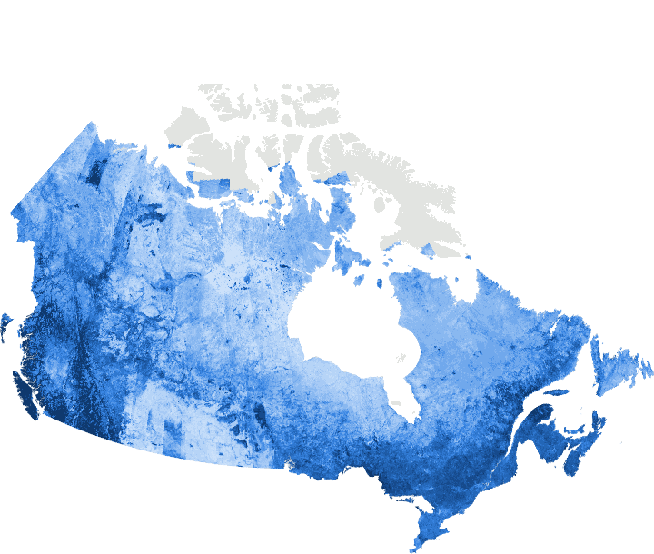

m; mapped from ICESat-2 samples

Source preview: own 2nd–98th percentile stretch; values outside the range saturate. Grey land has no valid displayed value.

Selected area · same variable, depth and year as the map · valid area and missing coverage reported

Additional source layers and their study roles are to be added. Output pixel spacing, source resolution and context radius remain distinct.

## Forests · Maps

Inspect each product before comparing it. Biomass, aboveground carbon and multi-pool vegetation carbon are different quantities.

#### McMaster/WWF forest carbon

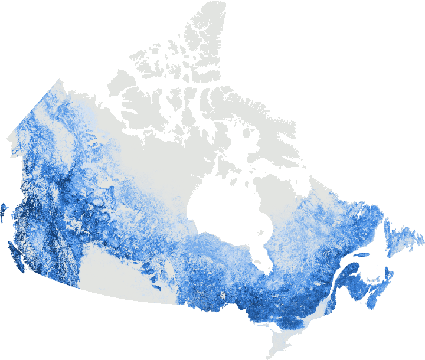

kg C/m² (AGB + BGB + dead plant)

Source preview: own 2nd–98th percentile stretch; values outside the range saturate. Grey land has no valid displayed value.

Selected area · same variable, depth and year as the map · valid area and missing coverage reported

## Stocks for a chosen area

For either domain: select a boundary, a product and a compatible pool/depth/year. Report what area is represented.

### At observed sites

Stock density at a stated interval/pool, usually kg C/m². Complete depth coverage and measurement/estimation flags retained.

Plot total requires its measured area. A sum of sampled sites is not a regional estimate.

### Within a chosen boundary

Pixel stock density × the represented area, summed over valid coverage. Report tonnes or Tg C, with missing area visible.

Alternative products are compared on common support; overlapping estimates are not added.

| Area summary | Value | Needed before calculation |
| --- | --- | --- |
| Boundary and size | Not selected | Canada, ecozone, province or supplied polygon |
| Product definition | Selection required | Quantity, version, depth/pool and year |
| Valid mapped area | Not calculated | Pixel areas, masks, coverage and boundary weights |
| Mean stock density | Not calculated | Area-weighted mean over valid area |
| Total carbon | Not calculated | Sum stock density × area; explicit mass unit |
| Uncertainty | Not calculated | Source statistic and defensible aggregation method |

**What makes area totals comparable?**

Same boundary and common valid area; compatible quantity, carbon pool, depth/datum and reference period. Show each product's own coverage too. Missing pixels are not zero, and partial coverage is not automatically scaled to the whole area.

For kg C/m², sum value × represented m². Divide kg by 1,000 for tonnes C or by 1,000,000,000 for Tg C. Concentration alone cannot supply this total.

## Then move to comparisons and tools

The summaries establish definitions, coverage and distributions. The comparison page then tests eligible alternatives; GEE apps remain planned.